# Data Analysis

It all starts with that. Exploring the data. Trying to make sense of it.

I had the Stack Overflow public dump from march 2014 with the users, posts, tags, etc. In total they are about 30GB. Because of their size, that could not fit in memory, and they format, XML, I decided to start fresh, with the Stack Exchange API.

### Function to get users from stack api

```python
import pandas as pd
import seaborn as sns
from datetime import datetime
import matplotlib as mpl
import matplotlib.pyplot as plt
import requests
import time
from glob import glob
```

```python
# seaborn config
sns.set_palette("deep", desat=.6)
sns.set_context(rc={"figure.figsize": (8, 4)})
np.random.seed(9221999)
```

```python
def get_users(p_sort=0, amount=1000):
    '''
    Get users ordered by a principle passed as a parameter

    Params:
        :sort(int, optional): a number that represent one of the orders:
            [reputation, creation, name, modified]
        :amount(int, optional): amount of users to get. Multiple of 1000
    '''

    # create the url
    url = 'http://api.stackexchange.com/2.2/users/?order=desc&sort={}&site=stackoverflow&key='+ app_key['key']
    page_size = '&pagesize=100'
    page =1
    order = ['reputation', 'creation', 'name', 'modified']

    # while there is data
    first = True
    ret = None
    while True:
        t1 = datetime.now()
        response = requests.get(url.format(order[p_sort])+page_size+'&page='+str(page))
        d= response.json()
        if first:
            ret = pd.DataFrame(d['items'])
            first = not first
        else:
            ret = pd.concat([ret,pd.DataFrame(d['items'])])

        # check if there is more
        if d['has_more']:
            # check if the limit has being breaked
            if ceil(amount/100.0) <= page:
                break
            page += 1
            print 'Going to page %d' %page
            t2 = datetime.now()

            # if it was quickier than 1/30 seconds, wait to call again
            delta = (t2 - t1)
            if (delta.microseconds < 34.000):
                time.sleep( (1/30.0) - delta.microseconds*1000)

            # check if there was the backoff message and wait
            if d.has_key('backoff'):
                time.sleep(d['backoff'])
        else:
            break
    return ret
```

```python
#and then, top 50k in reputation to a file
users = get_users(amount= 50000)
users.to_csv('users_50k.csv', index=False, encoding='utf-8')
```

The API gives a limit of 10k per day, 100 records per call. That is a max of 1,000,000 per day. Ok, right?

```python
users = pd.read_csv('users_50k.csv', encoding='utf-8', verbose=True)
users.shape
```

```
Tokenization took: 51.43 ms
Type conversion took: 196.68 ms
Parser memory cleanup took: 0.12 ms
Tokenization took: 17.94 ms
Type conversion took: 78.40 ms
Parser memory cleanup took: 0.01 ms
```

```
(50000, 21)
```

```python
print users.columns
users.head()
```

[output not shown]

|  | accept_rate | account_id | age | badge_counts | creation_date | display_name | is_employee | last_access_date | last_modified_date | link | ... | profile_image | reputation | reputation_change_day | reputation_change_month | reputation_change_quarter | reputation_change_week | reputation_change_year | user_id | user_type | website_url |
| --- | --- | --- | --- | --- | --- | --- | --- | --- | --- | --- | --- | --- | --- | --- | --- | --- | --- | --- | --- | --- | --- |
| 0 | 85 | 11683 | 38 | {u'gold': 296, u'silver': 4619, u'bronze': 5982} | 1222430705 | Jon Skeet | False | 1410636911 | 1410588133 | http://stackoverflow.com/users/22656/jon-skeet | ... | https://www.gravatar.com/avatar/6d8ebb117e8d83... | 709229 | 230 | 3470 | 21448 | 1835 | 74417 | 22656 | registered | http://csharpindepth.com |
| 1 | 91 | 14332 | 33 | {u'gold': 70, u'silver': 1675, u'bronze': 1809} | 1224432467 | Darin Dimitrov | False | 1410640322 | 1410106632 | http://stackoverflow.com/users/29407/darin-dim... | ... | https://www.gravatar.com/avatar/e3a181e9cdd475... | 539613 | 125 | 2500 | 14576 | 1370 | 53134 | 29407 | registered | http://stackoverflow.com/search?q=user%3a29407... |
| 2 | 92 | 52822 | 36 | {u'gold': 113, u'silver': 1490, u'bronze': 1822} | 1250527322 | BalusC | False | 1410641505 | 1410588436 | http://stackoverflow.com/users/157882/balusc | ... | https://www.gravatar.com/avatar/89927e2f4bde24... | 508539 | 200 | 3119 | 17969 | 1600 | 59846 | 157882 | registered | http://balusc.blogspot.com |
| 3 | 88 | 11975 | 36 | {u'gold': 96, u'silver': 1312, u'bronze': 1844} | 1222667162 | Marc Gravell | True | 1410623625 | 1410588133 | http://stackoverflow.com/users/23354/marc-gravell | ... | http://i.stack.imgur.com/NJcqr.png?s=128&g=1 | 492222 | 88 | 2853 | 15291 | 1463 | 51144 | 23354 | moderator | http://blog.marcgravell.com |
| 4 | NaN | 9266 | NaN | {u'gold': 50, u'silver': 500, u'bronze': 991} | 1221698729 | Hans Passant | False | 1410638169 | 1410621323 | http://stackoverflow.com/users/17034/hans-passant | ... | http://i.stack.imgur.com/Cii6b.png?s=128&g=1 | 485630 | 241 | 3384 | 19224 | 1761 | 70330 | 17034 | registered | NaN |

5 rows × 21 columns

### A little about the users

Analysing a little the 50k top users.

- most of the fields change with their use. Some of them could give good current statistics as reputation_change_xxx
- fixed fields: account_id, user_id
- almost fixed: age, display_name, is_employee, user_type

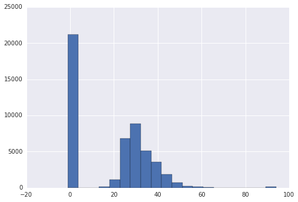

```python
# histogram of users age
users.age[users.age.isnull()]= -1
plt.hist(users.age,20)
```

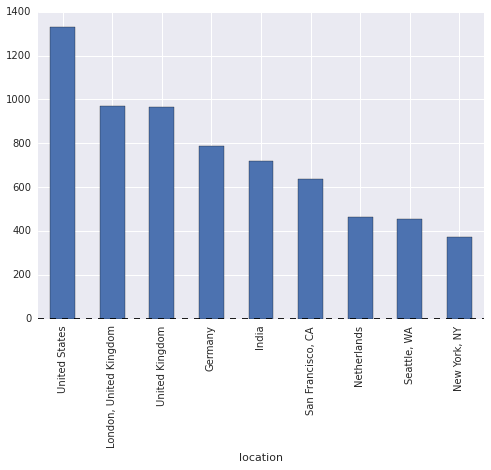

```python
users.location[users.location.isnull()]= 'Unk'
users.groupby('location')['user_id'].count().sort(ascending=False, inplace =False)[1:10].plot(kind='bar')
```

Conclusions:

- info is not normalized and not required in most fields
- may use website and description for getting more knowledge about the user
- may use reputation changes to update users/as a feature for group selection

### The Tags and users

To me, it seemed clear that the tags are the most normalized data on Stack Overflow and that could help me classify users and information. So, as a test set, I could get the tags of only the top 50k users.

```python
def dprint(msg, time=None):
    ''' Helper function to print date before msg '''
    if not time:
        time = datetime.now()
    print '{} - {}'.format(time.strftime('%Y-%m-%d %H:%M:%S'), msg)

def get_users_tags( p_client_list=None, p_amount=100,
                       first_client=1, cli_amount=100):
        '''
        Get the users tags. A list of user can be passed or a list of
        sequencial ids can be generated as the list of users.

        Params:
            :p_client_list(list, optional): list of users
            :p_amount(int, optional): the number of rows to be brought
            :first_client(int, optional): first id to be generated
            :cli_amount(int, optional): number of ids to be generated
        '''
        # create the url
        site = '&site=stackoverflow'
        key = '&key=' + 'XuUgyTQEsGuu1avMOxxnRw(('
        suffix = site+key
        prefix = 'http://api.stackexchange.com/2.2/'
        url = prefix+'users/{}/tags?order=desc&sort=popular'+suffix

        # users list
        id_str = ''
        if not p_client_list:
            p_client_list = range(first_client, first_client+cli_amount)
        for i in p_client_list:
            id_str += str(i) + ';'
        id_str = id_str[:-1]
        url = url.format(id_str)

        # get info
        return get_all_rows(url, p_amount)

# more generic function to fetch stack api rows
def get_all_rows(p_url, p_amount, p_pagesize=100, p_verbose=True):
        '''
        Fetch all rows. Takes care of the 30 call per second and the backoff
        command send by SO

        :param
        :p_url(str): the url that will be called over and over.
            It should not contain page param, as it will be appended
        :p_amount(int): the amount of information (rows) that should be
            retrieved
        :p_pagesize(int, optional): the amount of info that will be fetch in
            each page.
        :return: dataframe with info
        '''
        # initial info
        page_size = '&pagesize='+str(p_pagesize)
        page =1

        # while there is data
        first = True
        ret = None
        quota = 0
        while True:
            t1 = datetime.now()
            response = requests.get(p_url+page_size+'&page='+str(page))
            d= response.json()
            if first:
                ret = pd.DataFrame(d['items'])
                first = not first
            else:
                ret = pd.concat([ret,pd.DataFrame(d['items'])])
            quota = d['quota_remaining']

            # check if there is more
            if d['has_more']:
                # check if there is a limit and it if was braked
                if p_amount and ceil(p_amount/100.0) <= page:
                    break
                page += 1
                dprint('Going to page %d' %page)
                t2 = datetime.now()

                # if it was quickier than 1/30 seconds, wait to call again
                delta = (t2 - t1)
                if (delta.microseconds < 34.000):
                    time.sleep( (1/30.0) - delta.microseconds*1000)

                # check if there was the backoff message and wait
                if d.has_key('backoff'):
                    dprint('Backing off %d' %d['backoff'])
                    time.sleep(d['backoff'])
            else:
                break

        if p_verbose:
            dprint('Quota_remaining: %d' %quota)

        return ret
```

The most active users have a really ridicously amount of tags. Getting the famous Jon Skeet as example:

```python
# bring all his tags
tags = get_users_tags([22656], p_amount=None)
```

[output not shown]

```python
tags.count()
```

[output not shown]

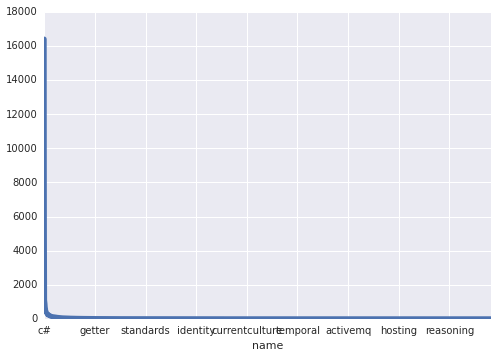

```python
# he cannot have so many points in all of them.
tags.groupby(['name'])['count'].sum().sort(ascending=False, inplace =False).plot(linewidth=5)
```

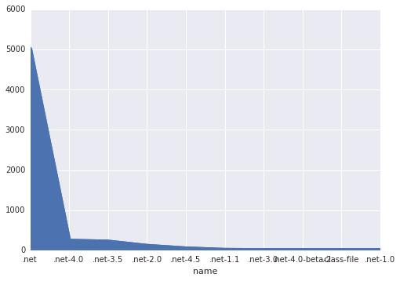

```python
# soooo, even him is not that good in ALL the tags he has. the top 10 maybe? Got you, Jon Skeet
tags.groupby(['name'])['count'].sum()[0:10].sort(ascending=False, inplace =False).plot(kind='area', linewidth=5)
```

The conclusion is that nobody knows everything. So, as I can get for each user in a page 100 tags, I'll do it.

### The tags - generally speaking

Getting tags for the first 50k users, I saved them in files (each day I could get only 10k users, but I did not do it, as I needed some calls to test other stuff) and another analysis could be made.

```python
files = glob('../Data/tags_top*.csv')
tags = None
for f in files:
    df = pd.read_csv(f)
    if isinstance(tags, pd.DataFrame ):
        tags = pd.concat([tags, df])
    else:
        tags = df
```

```python
print 'total tags', tags.shape
print 'unique tags', len(tags.name.unique())
print 'unique users', len(tags.user_id.unique())
```

```
 total tags (3401707, 6)
unique tags 33195
unique users 37114
```

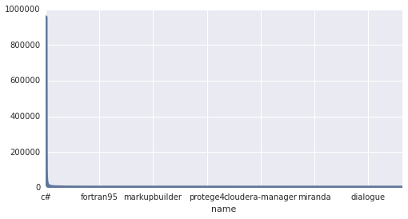

```python
# the relevancy of tags by points
tags.groupby(['name'])['count'].sum().sort(ascending=False, inplace =False).plot(linewidth=5)
```

```
name
c#               954727
java             873492
javascript       762801
php              663538
jquery           582558
c++              498710
python           424011
android          416965
html             359738
sql              321198
.net             316191
mysql            303539
asp.net          266416
css              263286
c                252814
iphone           226407
ios              220281
objective-c      217254
ruby-on-rails    181013
regex            163484
Name: count, dtype: int64
```

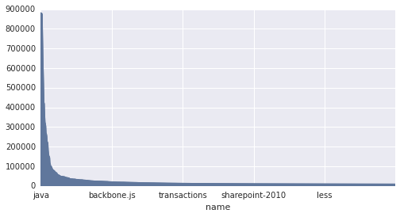

```python
# maybe the top 1000, by points
tags_count = tags.groupby(['name'])['count'].sum().sort(ascending=False, inplace =False)
print tags_count[0:20]
tags_count[1:1000].plot(linewidth=5, kind='area')
```

```
name
html           22033
java           21791
c#             19591
php            19542
jquery         19254
sql            18836
arrays         18627
string         18159
mysql          17869
regex          16811
css            16636
database       16285
xml            15708
performance    15668
json           14837
.net           14758
c++            14114
python         13647
ajax           13410
Name: user_id, dtype: int64
name
theory                  602
xcode5                  599
mouseevent              599
containers              598
log4net                 597
http-status-code-404    596
scheduled-tasks         595
metadata                594
settimeout              593
equals                  593
pass-by-reference       592
protocols               591
buffer                  591
c++-cli                 591
distinct                590
memory-allocation       590
sql-server-ce           589
viewmodel               589
inline                  588
uialertview             587
Name: user_id, dtype: int64
```

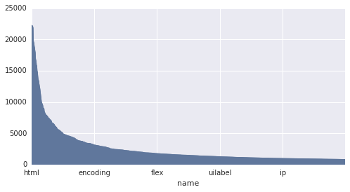

```python
# top 1000, by users
tags_users_count = tags.groupby(['name'])['user_id'].count()
print tags_users_count.sort(ascending=False, inplace =False)[1:20]
print tags_users_count.sort(ascending=False, inplace =False)[980:1000]
tags.groupby(['name'])['user_id'].count().sort(ascending=False, inplace =False)[1:1000].plot(linewidth=5, kind='area')
```

```python
# there is a difference between the amount of users and the amount of points they make for the tags. Which tags give more points?
tags_count = pd.merge(tags.groupby(['name'])['user_id'].count().reset_index(),
                      tags.groupby(['name'])['count'].sum().reset_index(),
                      on='name')
tags_count['ratio'] = tags_count['count']/tags_count['user_id']
```

```
name
c4               71.000000
xpages           63.394737
tridion          59.896552
atk4             58.750000
r                55.302508
docusign         53.666667
rally            48.736842
c#               48.732939
worklight        47.857143
livecode         46.000000
java             40.084989
clearcase-ucm    39.875000
spring-saml      38.000000
delphi           37.581835
Name: ratio, dtype: float64
```

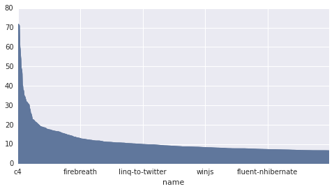

```python
print tags_count.groupby(['name'])['ratio'].sum().sort(ascending=False, inplace =False)[1:15]
tags_count.groupby(['name'])['ratio'].sum().sort(ascending=False, inplace =False)[1:1000].plot(linewidth=5, kind='area')
```

Seems that if we use only the 1000 more popular tags, we are not loosing much. Let's check this theory

```python
# the top 1000 tags data, users and all
top_tags = tags_count[tags_count.rank(ascending=False)<1000].index
top_tags_data= tags[tags.name.isin(top_tags)]
print 'total number of users - 1000 tags count' , top_tags_data['user_id'].nunique()
print 'total number of users - all tags count' , tags['user_id'].nunique()
```

[output not shown]

Ok. We can leave with this 4 users that do not have any of our top tags

If we get the tags that have more users:

```python
# the top 1000 tags data, users and all
top_users_tags = tags_users_count[tags_users_count.rank(ascending=False)<1000].index
top_users_tags_data= tags[tags.name.isin(top_users_tags)]
print 'total number of users - 1000 tags users' , top_users_tags_data['user_id'].nunique()
print 'total number of users - all tags users' , tags['user_id'].nunique()
```

```
total number of users - 1000 tags users 37109
total number of users - all tags users 37114
```

```python
# are they the same tags?
top_users_tags_data.name.unique() in (top_tags_data.name.unique())
```

```
True
```

```python
print 'New Avg Number of tags per user', top_tags_data.groupby('user_id')['name'].nunique().mean()
print 'New SD Number of tags per user', top_tags_data.groupby('user_id')['name'].nunique().std()
```

```
New Avg Number of tags per user 59.9588790084
New SD Number of tags per user 16.7667710848
```

```python
print 'New Avg Number of tags per user', top_users_tags_data.groupby('user_id')['name'].nunique().mean()
print 'New SD Number of tags per user', top_users_tags_data.groupby('user_id')['name'].nunique().std()
```

```
New Avg Number of tags per user 61.6216012288
New SD Number of tags per user 16.9869492262
```

Conclusions about the tags and the 50k users:

- most of the tags are used just a few times and have few users.
- even if I reduce the amounts of tags, I don't loose a lot of users.
- most of the times, a user will have interest in this tags